# cmetcalf_OriginalHomeworkCode_03

# Some of my best friends are Zombies…

[figure not shown]

*All love to Pedro Pascal*

```r
library(curl)
```

First load in the document (make sure to copy raw url not just repo’s):

```r
f <- curl("https://raw.githubusercontent.com/fuzzyatelin/fuzzyatelin.github.io/master/AN588_Fall23/zombies.csv")
d <- read.csv(f, header = TRUE, sep = ",", stringsAsFactors = FALSE)
head(d)
```

```
##   id first_name last_name gender   height   weight zombies_killed
## 1  1      Sarah    Little Female 62.88951 132.0872              2
## 2  2       Mark    Duncan   Male 67.80277 146.3753              5
## 3  3    Brandon     Perez   Male 72.12908 152.9370              1
## 4  4      Roger   Coleman   Male 66.78484 129.7418              5
## 5  5      Tammy    Powell Female 64.71832 132.4265              4
## 6  6    Anthony     Green   Male 71.24326 152.5246              1
##   years_of_education                           major      age
## 1                  1                medicine/nursing 17.64275
## 2                  3 criminal justice administration 22.58951
## 3                  1                       education 21.91276
## 4                  6                  energy studies 18.19058
## 5                  3                       logistics 21.10399
## 6                  4                  energy studies 21.48355
```

This data includes the first name, last name, and gender of the entire population of 1000 people who have survived the zombie apocalypse and are now ekeing out an existence somewhere on the East Coast, along with several other variables (height, weight, age, number of years of education, number of zombies they have killed, and college major).

## Calculate the population mean and standard deviation for each quantitative random variable (height, weight, age, number of zombies killed, and years of education). NOTE: You will not want to use the built in var() and sd() commands as these are for samples.

First to calculate the population mean, you can use the summary function to get a range of data for each variable, one of which is the mean:

```r
summary(d)
```

```
##        id          first_name         last_name            gender
##  Min.   :   1.0   Length:1000        Length:1000        Length:1000
##  1st Qu.: 250.8   Class :character   Class :character   Class :character
##  Median : 500.5   Mode  :character   Mode  :character   Mode  :character
##  Mean   : 500.5
##  3rd Qu.: 750.2
##  Max.   :1000.0
##      height          weight       zombies_killed   years_of_education
##  Min.   :54.15   Min.   : 90.29   Min.   : 0.000   Min.   :0.000
##  1st Qu.:64.68   1st Qu.:131.81   1st Qu.: 2.000   1st Qu.:2.000
##  Median :67.50   Median :142.89   Median : 3.000   Median :3.000
##  Mean   :67.63   Mean   :143.91   Mean   : 2.992   Mean   :2.996
##  3rd Qu.:70.38   3rd Qu.:156.28   3rd Qu.: 4.000   3rd Qu.:4.000
##  Max.   :80.53   Max.   :210.79   Max.   :11.000   Max.   :8.000
##     major                age
##  Length:1000        Min.   :10.66
##  Class :character   1st Qu.:18.07
##  Mode  :character   Median :19.90
##                     Mean   :20.05
##                     3rd Qu.:21.94
##                     Max.   :29.59
```

Then to calculate the standard deviation, we can create a function using population variance:

```r
h <- d$height #first assign the variable to a value we can put into our equation
pop_vh <- function(h) {sum((h-mean(h))^2)/(length(h))
} #calculate the population variance
pop_vh(h)
```

```
## [1] 18.55861
```

```r
pop_sdh <- function(h) {
  sqrt(pop_vh(h))
} #using the population variance we can then calculate standard deviation for the population
pop_sdh(h)
```

```
## [1] 4.30797
```

OR a shorter way found through stackoverflow is:

```r
sdh <- function(h) sqrt(mean((h-mean(h))^2))
sdh(h)
```

```
## [1] 4.30797
```

As you can see this gives the same standard deviation for the population with much shorter code.

Weight:

```r
w <- d$weight
sdw <- function(w) sqrt(mean((w-mean(w))^2)) #you could still use the sdh function created previously, but for the sake of organization in this assignment each one is given their own function assignment
sdw(w)
```

```
## [1] 18.39186
```

Zombies Killed:

```r
z <- d$zombies_killed
sdz <- function(z) sqrt(mean((z-mean(z))^2))
sdz(z)
```

```
## [1] 1.747551
```

Years of Education:

```r
e <- d$years_of_education
sde <- function(e) sqrt(mean((e-mean(e))^2))
sde(e)
```

```
## [1] 1.675704
```

Age:

```r
a <- d$age
sda <- function(a) sqrt(mean((a-mean(a))^2))
sda(a)
```

```
## [1] 2.963583
```

## Use {ggplot} to make boxplots of each of these variables by gender.

First have to load in packages with library() and then outline graphics such as what you are going “by” using filter and then what variable is being measured. You can also color the boxes using the scale_fill_manual command and even add a title. Also this solution is taken from Week 3 modules that was Jimmy’s example becuase this provided a clear example as well as piping to make it one code block.

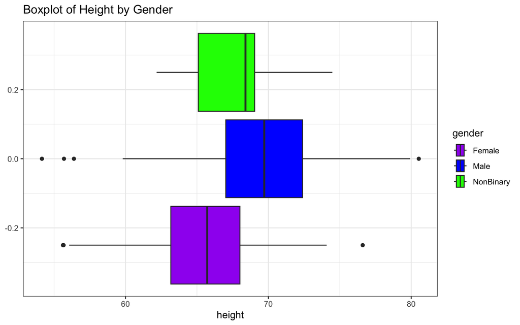

```r
library(ggplot2) #have to load in correct packages!
library(dplyr)
d %>% filter(gender == "Female" | gender == "Male" | gender == "NonBinary") %>%
  ggplot(aes(x = height, fill = gender)) +
  geom_boxplot() +
  scale_fill_manual(values = c("purple", "blue", "green")) +
  ggtitle("Boxplot of Height by Gender") + theme_bw()
```

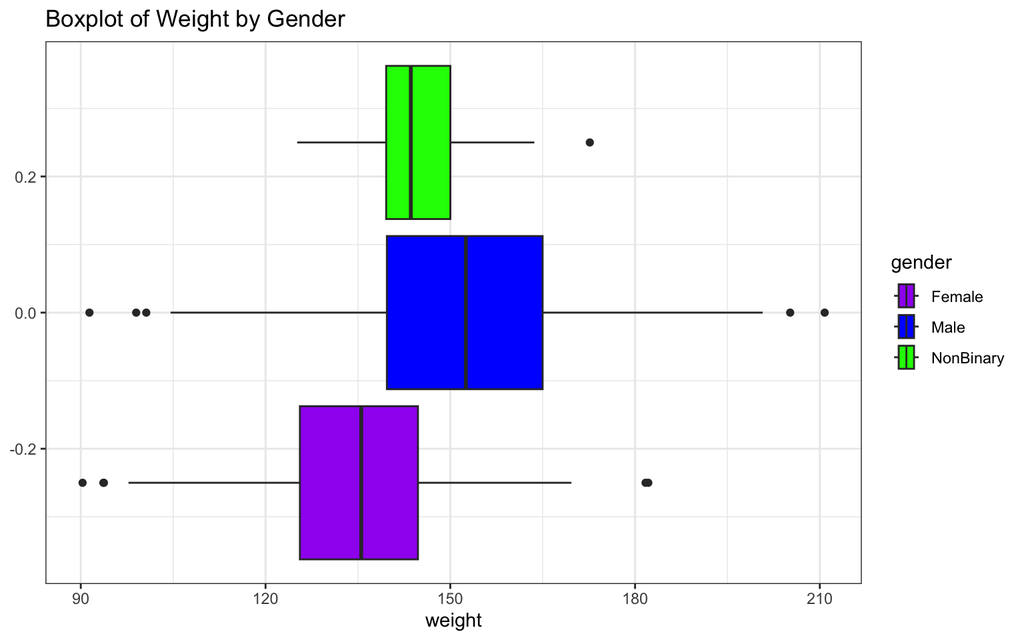

```r
d %>% filter(gender == "Female" | gender == "Male" | gender == "NonBinary") %>%
  ggplot(aes(x = weight, fill = gender)) +
  geom_boxplot() +
  scale_fill_manual(values = c("purple", "blue", "green")) +
  ggtitle("Boxplot of Weight by Gender") + theme_bw()
```

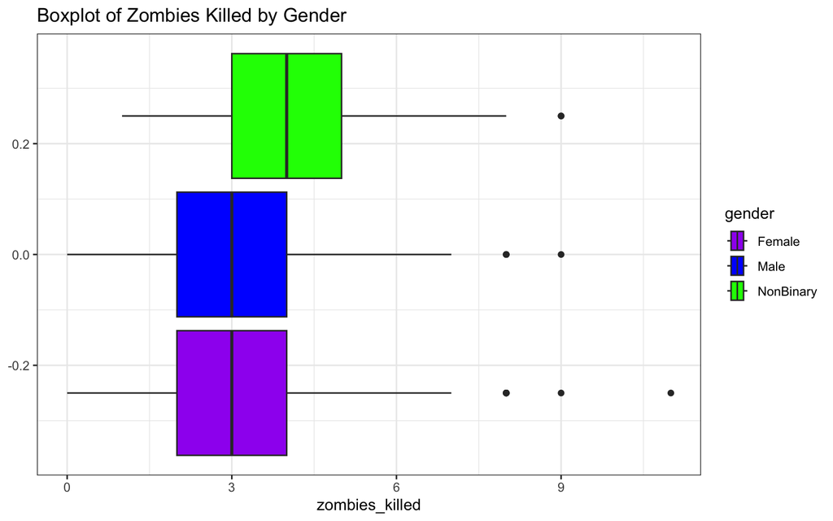

```r
d %>% filter(gender == "Female" | gender == "Male" | gender == "NonBinary") %>%
  ggplot(aes(x = zombies_killed, fill = gender)) +
  geom_boxplot() +
  scale_fill_manual(values = c("purple", "blue", "green")) +
  ggtitle("Boxplot of Zombies Killed by Gender") + theme_bw()
```

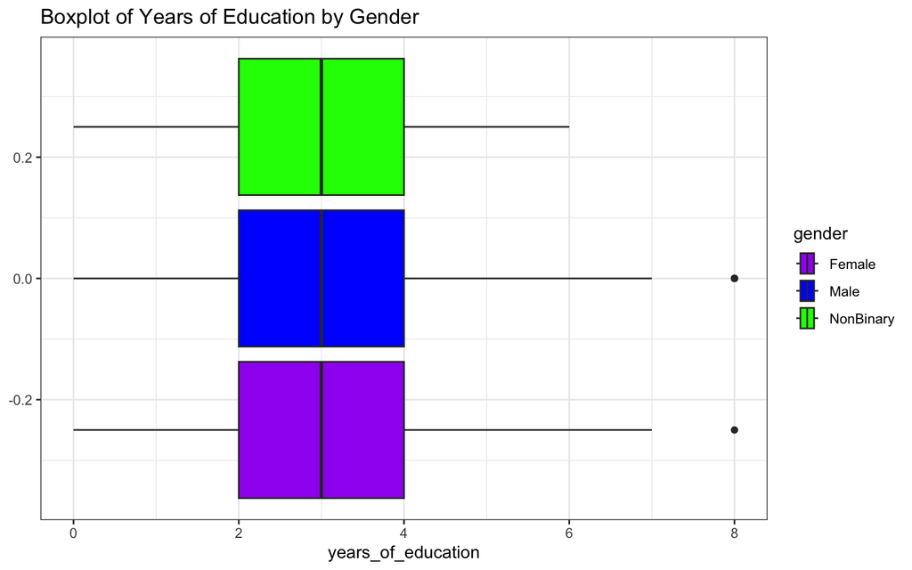

```r
d %>% filter(gender == "Female" | gender == "Male" | gender == "NonBinary") %>%
  ggplot(aes(x = years_of_education, fill = gender)) +
  geom_boxplot() +
  scale_fill_manual(values = c("purple", "blue", "green")) +
  ggtitle("Boxplot of Years of Education by Gender") + theme_bw()
```

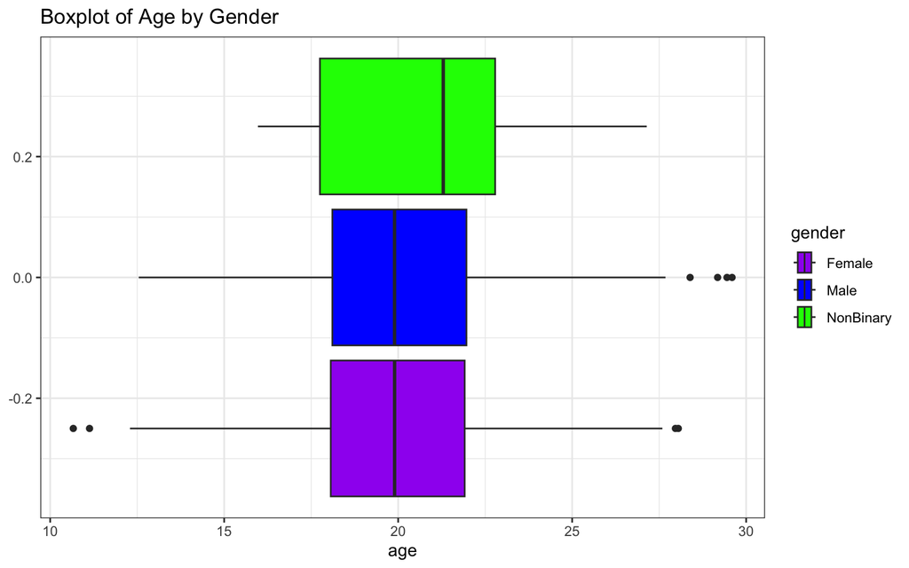

```r
d %>% filter(gender == "Female" | gender == "Male" | gender == "NonBinary") %>%
  ggplot(aes(x = age, fill = gender)) +
  geom_boxplot() +
  scale_fill_manual(values = c("purple", "blue", "green")) +
  ggtitle("Boxplot of Age by Gender") + theme_bw()
```

## Use {ggplot} to make scatterplots of height and weight in relation to age. Do these variables seem to be related? In what way?

We would use a bivariate scatterplot here:

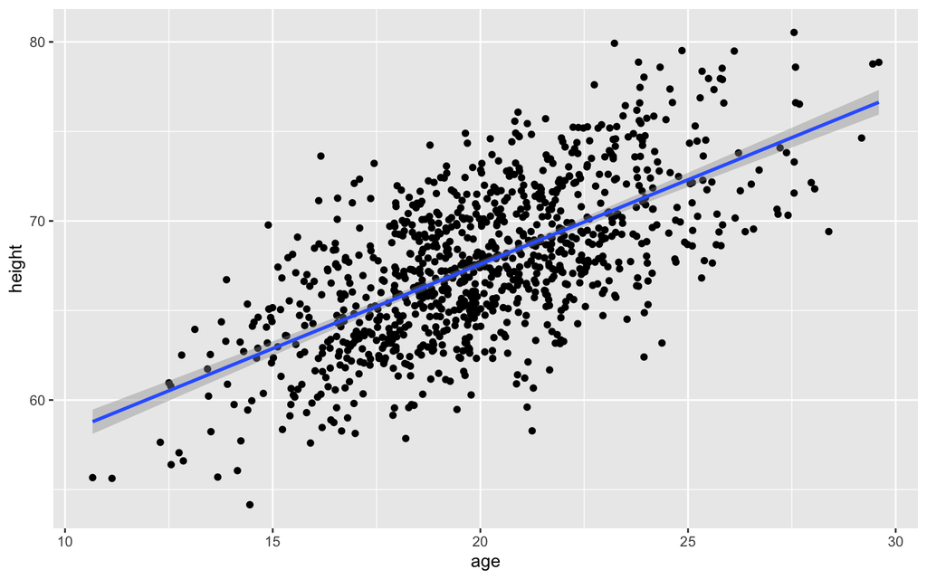

```r
p <- ggplot(data = d, aes(x = age, y = height))
p <- p + geom_point()
p <- p + geom_smooth(method = "lm")
p
```

Now for weight:

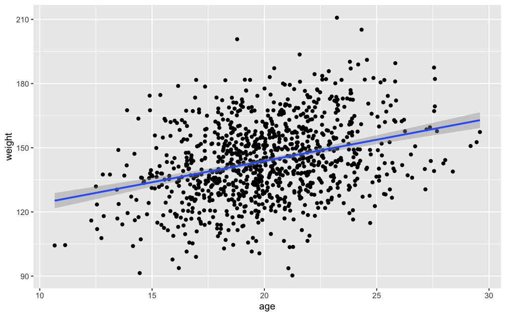

```r
p <- ggplot(data = d, aes(x = age, y = weight))
p <- p + geom_point()
p <- p + geom_smooth(method = "lm")
p
```

They do seem to be related in that the majority is around 20 years of age for both variables and concentrate around a positive sloped line of best fit. Therefore, both height and weight increase with age but the weight plot does appear to have more spread.

## Using histograms and Q-Q plots, check whether the quantitative variables seem to be drawn from a normal distribution. Which seem to be and which do not (hint: not all are drawn from the normal distribution)? For those that are not normal, can you determine from which common distribution they are drawn?

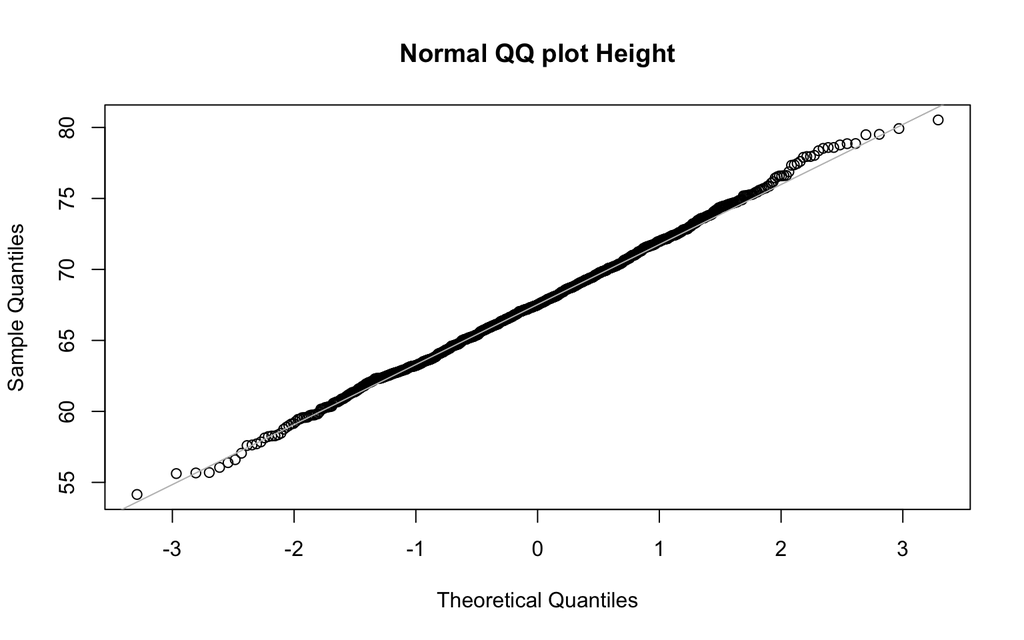

```r
qqnorm(d$height, main = "Normal QQ plot Height")
qqline(d$height, col = "gray")
```

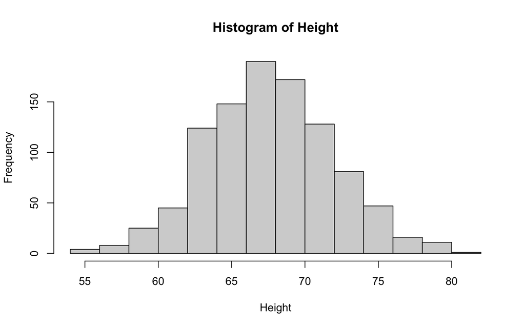

```r
hist(d$height, main = "Histogram of Height",
     xlab = "Height")
```

Points of the QQ plot lie pretty evenly on the line and the histogram shows equal distribution with it peaking around the mean, so these appear normal.

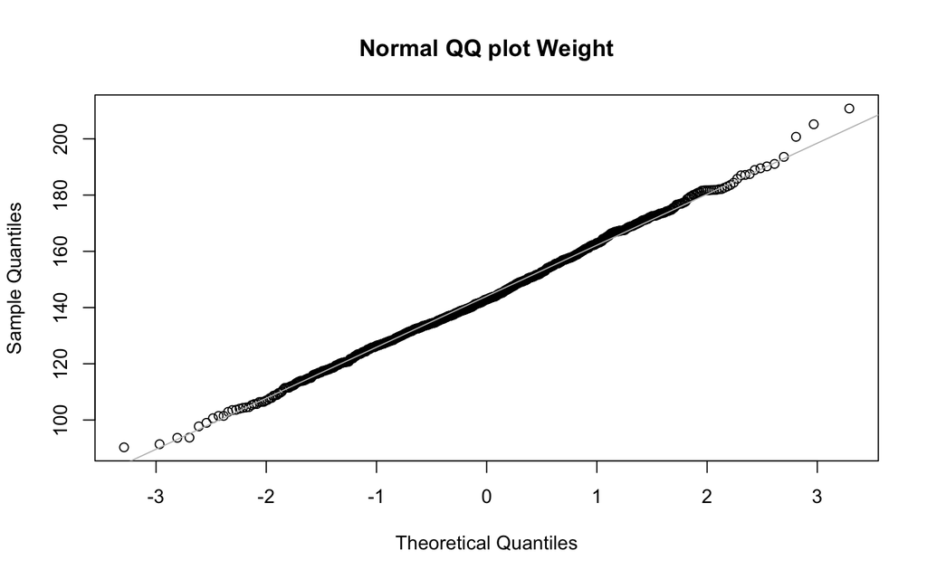

```r
qqnorm(d$weight, main = "Normal QQ plot Weight")
qqline(d$weight, col = "gray")
```

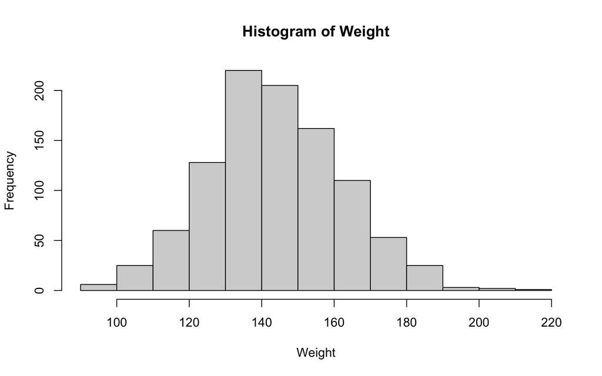

```r
hist(d$weight, main = "Histogram of Weight",
     xlab = "Weight")
```

Weight does the same as height with centering along the line and concentrating amongst the mean, so also a relatively normal distribution.

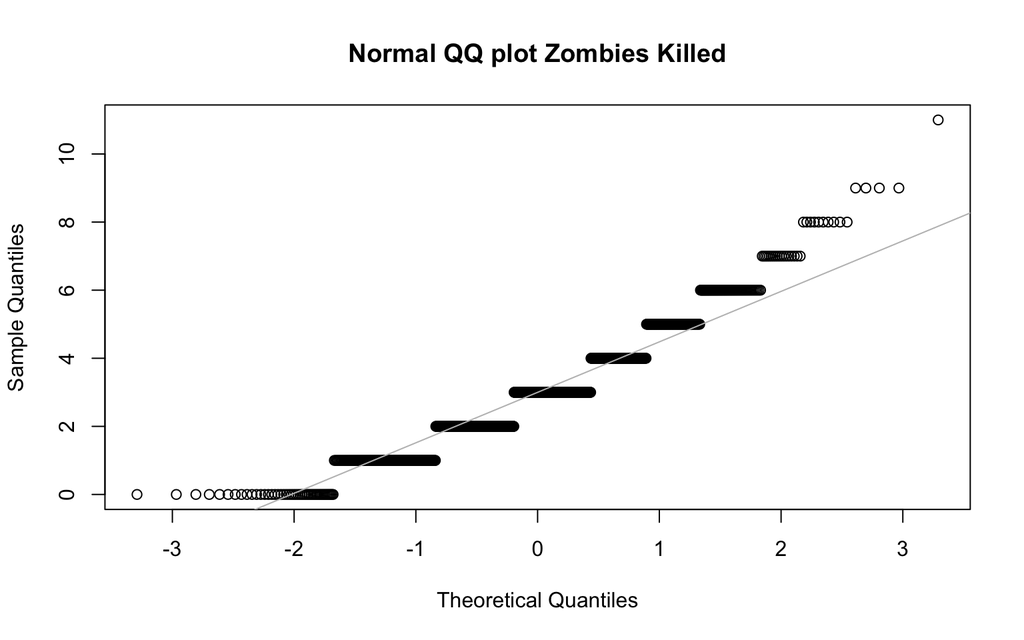

```r
qqnorm(d$zombies_killed, main = "Normal QQ plot Zombies Killed")
qqline(d$zombies_killed, col = "gray")
```

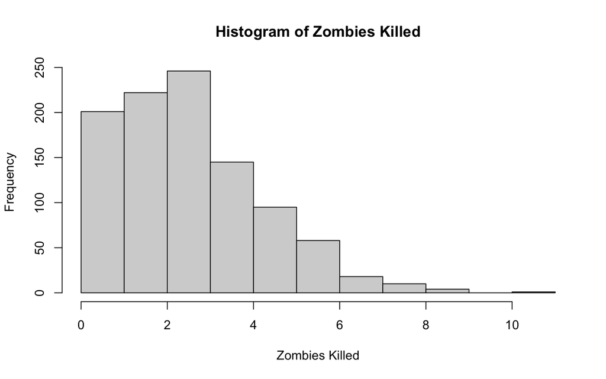

```r
hist(d$zombies_killed, main = "Histogram of Zombies Killed",
     xlab = "Zombies Killed")
```

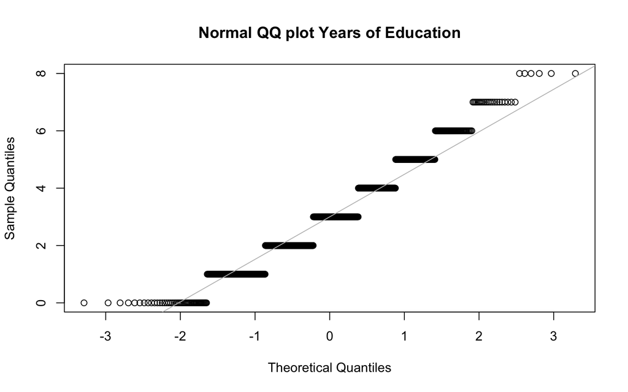

```r
qqnorm(d$years_of_education, main = "Normal QQ plot Years of Education")
qqline(d$years_of_education, col = "gray")
```

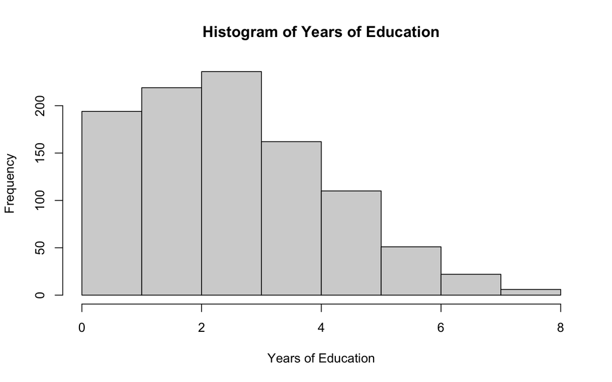

```r
hist(d$years_of_education, main = "Histogram of Years of Education",
     xlab = "Years of Education")
```

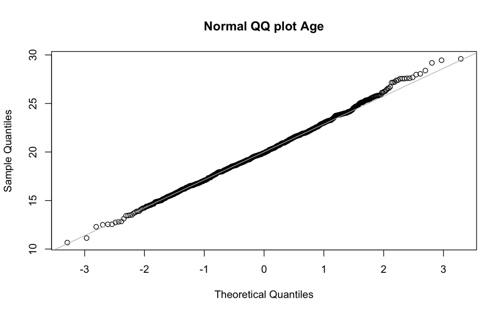

```r
qqnorm(d$age, main = "Normal QQ plot Age")
qqline(d$age, col = "gray")
```

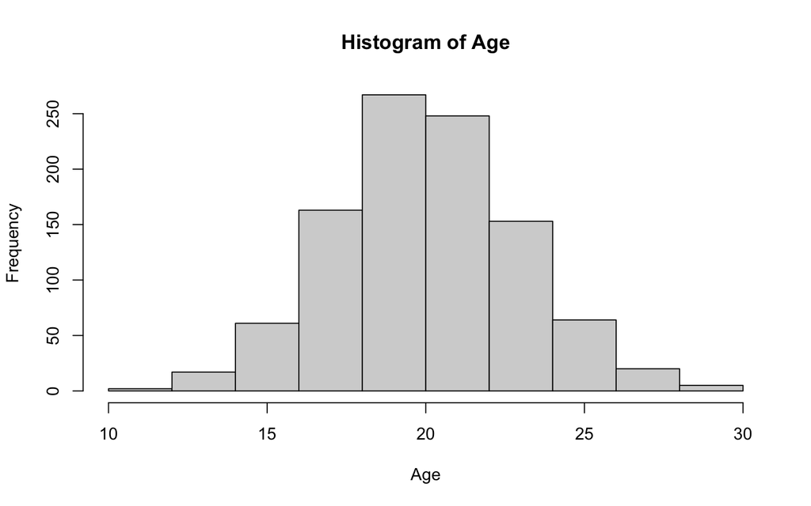

```r
hist(d$age, main = "Histogram of Age",
     xlab = "Age")
```

The age plots appear to be a normal distribution, again being concentrated around the line in the qqplot and peaking around the mean in the histogram with only small variation.

## Now use the sample() function to sample ONE subset of 30 zombie survivors (without replacement) from this population and calculate the mean and sample standard deviation for each variable. Also estimate the standard error for each variable, and construct the 95% confidence interval for each mean. Note that for the variables that are not drawn from the normal distribution, you may need to base your estimate of the CIs on slightly different code than for the normal…

```r
length(d) #denotes number of columns that we need to keep with our sample
```

```
## [1] 10
```

We have to take a sample from the rows (observations) of the dataframe but keep the columns (variables) with them to measure the mean:

```r
set.seed(30)
subsetsample2 <- d[sample(nrow(d), 30, replace = FALSE), ] #remember brackets denote whether you sample from [row, column]
subsetsample2
```

```
##      id first_name last_name    gender   height   weight zombies_killed
## 330 330   Lawrence    Medina      Male 67.21994 162.9205              6
## 253 253    Heather      Hart    Female 65.08853 128.8316              1
## 306 306     Gloria    Morgan    Female 68.09022 142.8512              1
## 942 942      Susan Patterson    Female 64.67957 134.2557              3
## 269 269     Donald     Smith      Male 61.77285 133.8740              8
## 460 460      Linda      Rose    Female 60.16201 117.8014              0
## 522 522   Patricia     Brown    Female 67.49037 148.9743              3
## 315 315      Tammy    Martin    Female 65.69532 123.4174              5
## 842 842      Marie  Marshall    Female 57.71565 116.1210              6
## 29   29      Roger     Perry      Male 64.64341 135.9254              4
## 188 188     Donald     Hicks      Male 71.49300 162.2126              5
## 435 435     Thomas  Phillips      Male 80.52980 187.4691              3
## 836 836      Susan   Hawkins    Female 69.35963 133.1018              3
## 304 304     Robert    Parker      Male 73.60436 161.1474              3
```

[output cut: 47 more lines]

Height:

```r
shm <- mean(subsetsample2$height)
shd <- sd(subsetsample2$height)
she <- sd(subsetsample2$height)/sqrt(length(subsetsample2$height)) #standard error equation
shm #outputs mean of height variable for sample hence ("s", "h", "m")
```

```
## [1] 67.00077
```

```r
shd
```

```
## [1] 5.205216
```

```r
she
```

```
## [1] 0.9503381
```

Then we can construct a confidence interval (using an example from module):

```r
lower <- shm - qnorm(1 - 0.05/2) * she  # (1-alpha)/2 each in the upper and lower tails of the distribution
upper <- shm + qnorm(1 - 0.05/2) * she  # (1-alpha)/2 each in the upper and lower tails of the distribution
cih <- c(lower, upper)
cih #confidence interval for height output
```

```
## [1] 65.13814 68.86340
```

Weight:

```r
swm <- mean(subsetsample2$weight)
swd <- sd(subsetsample2$weight)
swe <- sd(subsetsample2$weight)/sqrt(length(subsetsample2$weight))
swm
```

```
## [1] 144.5304
```

```r
swd
```

```
## [1] 19.81065
```

```r
swe
```

```
## [1] 3.616912
```

```r
lower <- swm - qnorm(1 - 0.05/2) * swe  # (1-alpha)/2 each in the upper and lower tails of the distribution
upper <- swm + qnorm(1 - 0.05/2) * swe  # (1-alpha)/2 each in the upper and lower tails of the distribution
ciw <- c(lower, upper)
ciw #confidence interval for weight output
```

```
## [1] 137.4414 151.6194
```

Zombies Killed (not normal distribution):

```r
szm <- mean(subsetsample2$zombies_killed)
szd <- sd(subsetsample2$zombies_killed)
sze <- sd(subsetsample2$zombies_killed)/sqrt(length(subsetsample2$zombies_killed))
szm
```

```
## [1] 3.233333
```

```r
szd
```

```
## [1] 2.028815
```

```r
sze
```

```
## [1] 0.3704093
```

```r
lower <- szm - qnorm(1 - 0.05/2) * sze  # (1-alpha)/2 each in the upper and lower tails of the distribution
upper <- szm + qnorm(1 - 0.05/2) * sze  # (1-alpha)/2 each in the upper and lower tails of the distribution
ciz <- c(lower, upper)
ciz #confidence interval for zombies killed output
```

```
## [1] 2.507344 3.959322
```

*struggled to find way to calculate a CI for a non-normal distribution, struggled with using the CLT, any tips? May be a Poisson distribution so as my peer commentor Sam recommended, we could use the poisson.test() function:

```r
poisson.test(length(subsetsample2$zombies_killed), conf.level = 0.95)
```

```
##
##  Exact Poisson test
##
## data:  length(subsetsample2$zombies_killed) time base: 1
## number of events = 30, time base = 1, p-value < 2.2e-16
## alternative hypothesis: true event rate is not equal to 1
## 95 percent confidence interval:
##  20.24087 42.82687
## sample estimates:
## event rate
##         30
```

Years of Education (not normal distribution):

```r
sem <- mean(subsetsample2$years_of_education)
sed <- sd(subsetsample2$years_of_education)
see <- sd(subsetsample2$years_of_education)/sqrt(length(subsetsample2$years_of_education))
sem
```

```
## [1] 2.833333
```

```r
sed
```

```
## [1] 0.9855275
```

```r
see
```

```
## [1] 0.1799319
```

```r
lower <- sem - qnorm(1 - 0.05/2) * see  # (1-alpha)/2 each in the upper and lower tails of the distribution
upper <- sem + qnorm(1 - 0.05/2) * see  # (1-alpha)/2 each in the upper and lower tails of the distribution
cie <- c(lower, upper)
cie #confidence interval for years of education output
```

```
## [1] 2.480673 3.185993
```

Assuming it may be a poisson distribution like zombies killed:

```r
poisson.test(length(subsetsample2$years_of_education), conf.level = 0.95)
```

```
##
##  Exact Poisson test
##
## data:  length(subsetsample2$years_of_education) time base: 1
## number of events = 30, time base = 1, p-value < 2.2e-16
## alternative hypothesis: true event rate is not equal to 1
## 95 percent confidence interval:
##  20.24087 42.82687
## sample estimates:
## event rate
##         30
```

Issue with this is it gives the same as above, so this may not be the solution we are looking for. But I will leave it as one possible way to calculate a CI for a non-normal distribution.

Age:

```r
sam <- mean(subsetsample2$age)
sad <- sd(subsetsample2$age)
sae <- sd(subsetsample2$age)/sqrt(length(subsetsample2$age))
sam
```

```
## [1] 19.37349
```

```r
sad
```

```
## [1] 3.325175
```

```r
sae
```

```
## [1] 0.6070911
```

```r
lower <- sam - qnorm(1 - 0.05/2) * sae  # (1-alpha)/2 each in the upper and lower tails of the distribution
upper <- sam + qnorm(1 - 0.05/2) * sae  # (1-alpha)/2 each in the upper and lower tails of the distribution
cia <- c(lower, upper)
cia #confidence interval for age output
```

```
## [1] 18.18361 20.56336
```

## Now draw 99 more random samples of 30 zombie apocalypse survivors, and calculate the mean for each variable for each of these samples. Together with the first sample you drew, you now have a set of 100 means for each variable (each based on 30 observations), which constitutes a sampling distribution for each variable. What are the means and standard deviations of this distribution of means for each variable? How do the standard deviations of means compare to the standard errors estimated in [5]? What do these sampling distributions look like (a graph might help here)? Are they normally distributed? What about for those variables that you concluded were not originally drawn from a normal distribution?

Using the replicate function we can do a sample 99 more times, which we are going to do by variable since there did not seem an easy way to calculate by variable other than telling it to take the sample from each column.

```r
ssh <- replicate (99, mean(sample(d$height, size = 30, replace =FALSE))) #will replicate 99 times with samples of size 30 for height and take the means of them so that we have 99 means
ssw <- replicate (99, mean(sample(d$weight, size = 30, replace =FALSE)))
ssz <- replicate (99, mean(sample(d$zombies_killed, size = 30, replace =FALSE)))
sse <- replicate (99, mean(sample(d$years_of_education, size = 30, replace =FALSE)))
ssa <- replicate (99, mean(sample(d$age, size = 30, replace =FALSE)))
```

The output of this is going to be 99 means per variable, and added to the sample previous you would have the 100 means total.

Then to get a mean and standard deviation of this sampling distribution we just take the mean of all of the means per variable.

```r
mean(ssh)
```

```
## [1] 67.66682
```

```r
mean(ssw)
```

```
## [1] 143.8966
```

```r
mean(ssz)
```

```
## [1] 3.03165
```

```r
mean(sse)
```

```
## [1] 3.034007
```

```r
mean(ssa)
```

```
## [1] 20.10189
```

```r
sd(ssh)
```

```
## [1] 0.7030253
```

```r
sd(ssw)
```

```
## [1] 3.102199
```

```r
sd(ssz)
```

```
## [1] 0.2994467
```

```r
sd(sse)
```

```
## [1] 0.3150776
```

```r
sd(ssa)
```

```
## [1] 0.5380334
```

I will use qqplots for distributions and to see if they are normal distributions:

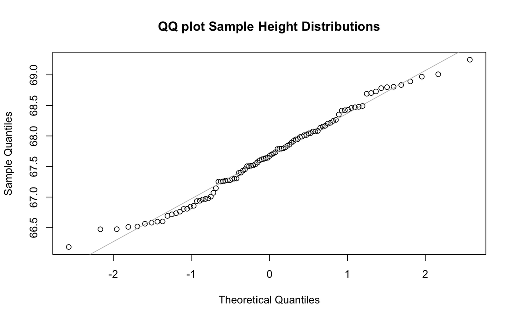

```r
qqnorm(ssh, main = "QQ plot Sample Height Distributions")
qqline(ssh, col = "gray")
```

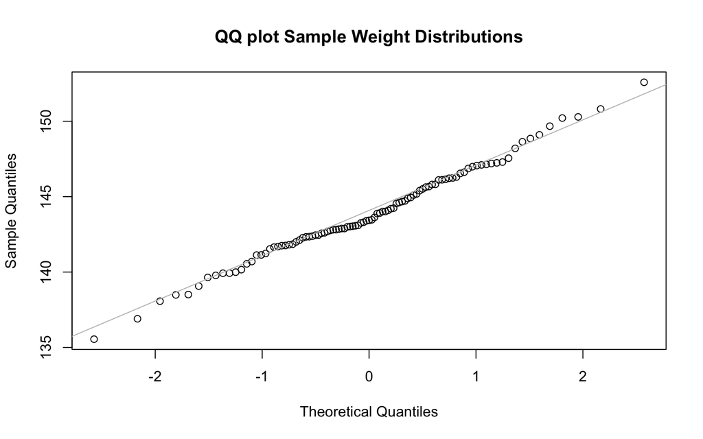

```r
qqnorm(ssw, main = "QQ plot Sample Weight Distributions")
qqline(ssw, col = "gray")
```

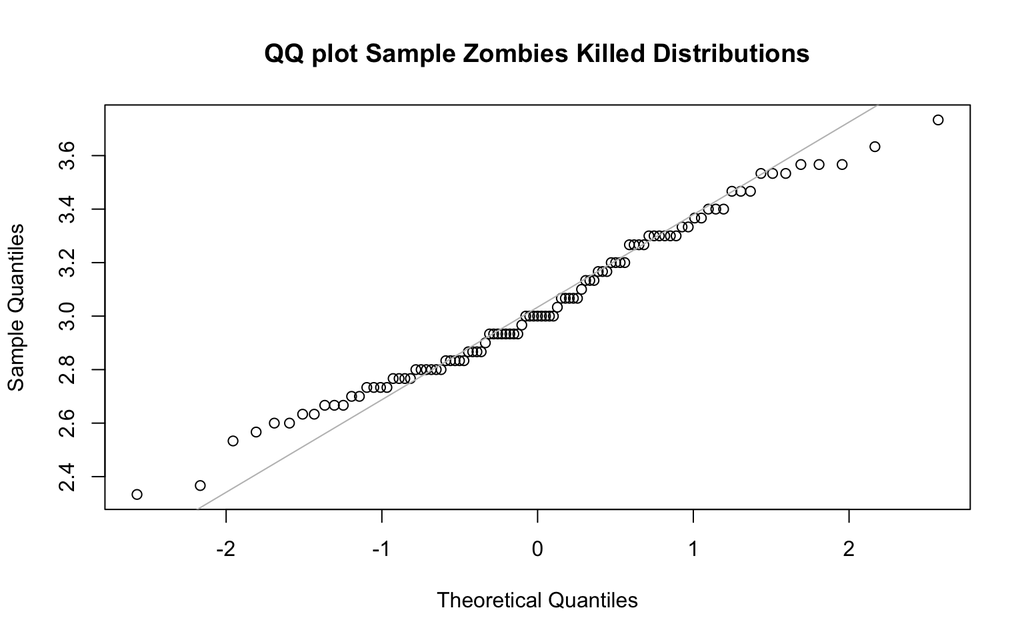

```r
qqnorm(ssz, main = "QQ plot Sample Zombies Killed Distributions")
qqline(ssz, col = "gray")
```

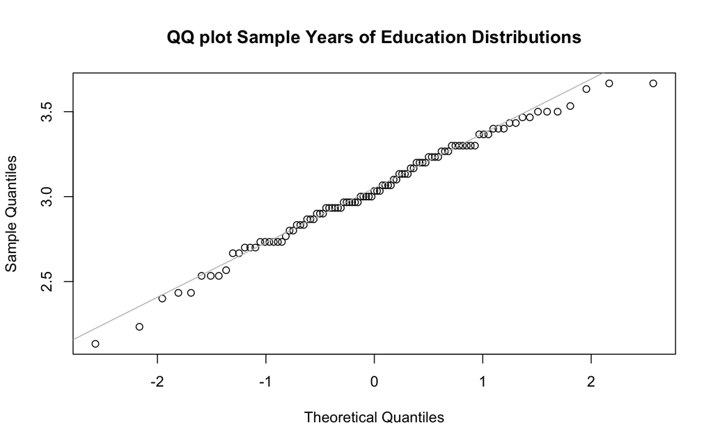

```r
qqnorm(sse, main = "QQ plot Sample Years of Education Distributions")
qqline(sse, col = "gray")
```

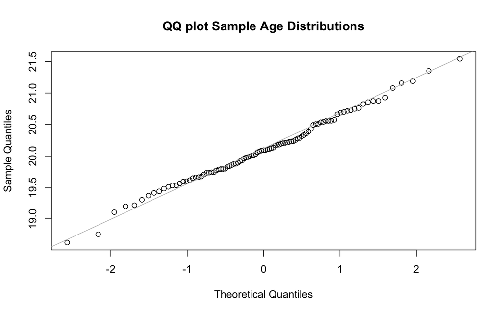

```r
qqnorm(ssa, main = "QQ plot Sample Age Distributions")
qqline(ssa, col = "gray")
```

They all seem relatively normal however there is some skewing around -1 and 1 deviations from the mean.

### Challenges Faced:

The first challenge I faced was finding a way to calculate standard deviations of each variable in an easily repeatable way, which I actually found the solution for online as mentioned above. Another challenge was standard error, since initially I did not use the correct function and in fact it was much simpler once I referenced code from the modules. Third challenge I faced was then the confidence intervals for distributions that are not normal, since I could not find an understandable way to apply the CLT technique in my code and did not completely understand it, which I still struggle to. Fourth, taking the initial subset sample was extremely difficult because the way the sample() function is set up is it automatically takes from variables unless you use the brackets to correctly sample from the rows (observations), which I eventually figured out. Finally, the last question posed an extreme challenge with repeating the sampling and then taking measurements from it. I wanted an easier way to take the means and sd of each variable for each sample in a way that made logical sense, but dissappointedly could not find it.